# PEC 1

Gene García Torres

2024-11-06

# PEC 1

## 1. Resumen

Este estudio presenta un análisis exploratorio de datos de metabolómica con el objetivo de identificar patrones y correlaciones en los niveles de metabolitos. Utilizando R y el contenedor SummarizedExperiment, se integraron datos de abundancia de metabolitos, información de muestras y detalles específicos de cada metabolito, consolidando así los datos para una exploración robusta.

Este estudio aporta una base para investigaciones futuras, recomendando validar los hallazgos y enfocar estudios en metabolitos clave. Los métodos y herramientas empleados aquí destacan la utilidad de enfoques estadísticos y visuales para una comprensión profunda de datos metabolómicos complejos.

## 2. Objetivos del estudio

Los objetivos dentro del reporte son los siguientes.

- Seleccionar un dataset de metabolómica que podéis obtener de o Este repositorio de github: https://github.com/nutrimetabolomics/metaboData/ o Si lo preferís podéis usar algún dataset del repositorio metabolomicsWorkbench
- Una vez descargados los datos cread un contenedor del tipo SummarizedExperiment que contenga los datos y los metadatos (información acerca del dataset, las filas y las columnas). La clase SummarizedExperiment es una extensión de ExpressionSet y muchas aplicaciones o bases de datos (como metabolomicsWorkbench) lo utilizan en vez de usar expressionSet.
- Llevad a cabo una exploración del dataset que os proporcione una visión general del mismo en la línea de lo que hemos visto en las actividades

## 3. Materiales y Metodos.

### 3.1 Origen y Naturaleza de los datos.

Para la exploración de datos del reporte se opto por recurrir al repositorio de github proporcionado por el docente, en donde se eligió un data set con nombre de “2018-MetabotypingPaper”, el cual contiene datos utilizados en el articulo “Metabotypes of response to bariatric surgery independent of the magnitude of weight loss”.

Estos datos fueron publicados dentro del sitio web del articulo así como en su propio repositorio dentro de github el cual contiene el siguiente contenido:

- DDataInfo_S013.csv: Metadata. Información en cada columna del archivo “DataValues_S013.csv”.
- DataValues_S013.csv: Valores clinicos y metabolomicos de 39 pacientes en 5 etapas diferentes.
- AAInformation_S006.csv: Información adicional de metabolitos dentro del archivo “DataValues_S013.csv.

La naturaleza de los datos, es metabolomicoa y clinica conteniendo las mediciones de abundacion de metabolitos y datos clinicos relevantes en los pacientes.

### 3.2 Herramientas Informaticas y bioinformaticas.

Para la exploración de los datos se utilizo el programa estadistico de R, y la libreria especifica de **“SummarizedExperiment”** para manipular los datos de experimentos.

El modo en que se trabajaron los datos fue **ExpresionSet** o en este caso **SummarizedExperiment** que facilito el manjero y analisis de los datos metabolomicos.

### 3.3 Procedimiento General de Análisis

Se generaron gráficos de distribución y correlación, tales como histogramas, mapas de calor, y boxplots, para explorar la variabilidad en los datos y eliminar posibles outliers o patrones de ruido.

## 4. Resultados

### 4.1 Preparación de datos.

Para poder realizar una exploracion de los datos se utilizo la libreria **“SummarizedExperiment”** la cual forma parte de Bioconductor.

```r
library(SummarizedExperiment)
```

Después se comienza analizando un poco los datos adquiridos del repositorio, en donde observamos primeros los “Data Values”, en donde se encuentran los datos clínicos de los pacientes y podemos ver que tiene 39 pacientes y 695 variables.

```r
# Leer los datos desde el archivo de valores de metabolitos
data_values <- read.csv("DataValues_S013.csv", row.names = 1)
names(data_values[6:10])
```

```
## [1] "MEDDM_T0"  "MEDCOL_T0" "MEDINF_T0" "MEDHTA_T0" "GLU_T0"
```

Y se muestran un poco el como es la estructura de los datos y en donde encontramos que tenemos valores N.A los cuales se filtraran mas adelante.

```r
head(data_values[0:9])
```

```
##   SUBJECTS SURGERY AGE GENDER Group MEDDM_T0 MEDCOL_T0 MEDINF_T0 MEDHTA_T0
## 1        1 by pass  27      F     1        0         0         0         1
## 2        2 by pass  19      F     2        0         0         0         0
## 3        3 by pass  42      F     1        0         0         0         0
## 4        4 by pass  37      F     2        0         0         0         0
## 5        5 tubular  42      F     1        0         0         0         0
## 6        6 by pass  24      F     2        0         0         0         0
```

```r
table(is.na(data_values))
```

```
##
## FALSE  TRUE
## 23715  3390
```

Después se leerán los datos dentro del archivo **“DataInfo_S013.csv”**, el cual contiene los meta datos asociados a cada muestra en el conjunto de datos y **“AAInformation_S006”** la cual contiene informacion adicional de los metabolitos.

```r
# Leer metadatos de muestras desde el archivo
sample_info <- read.csv("DataInfo_S013.csv", row.names = 1)
metabolite_info <- read.csv("AAInformation_S006.csv", row.names = 1)
```

En este paso, estamos creando un objeto SummarizedExperiment, una estructura de datos diseñada para integrar y manejar datos experimentales en R, específicamente en análisis de datos ómicos (como metabolómica, transcriptómica, etc.).

```r
# Asegurarse de que las columnas de sample_info coincidan con las columnas de data_values
sample_info <- sample_info[match(colnames(data_values), rownames(sample_info)), ]
# Asegurarse de que las filas de metabolite_info coincidan con las filas de data_values
metabolite_info <- metabolite_info[match(rownames(data_values), rownames(metabolite_info)), ]
```

```r
se <- SummarizedExperiment(
  assays = list(counts = as.matrix(data_values)),
  colData = sample_info,
  rowData = metabolite_info
)
```

Este objeto organiza la información en tres componentes principales:

- **assays:** Aquí es donde almacenamos la matriz de datos (data_matrix) con los valores metabolómicos. Estos valores representan las abundancias de cada metabolito en cada muestra.

  La matriz se guarda en una lista (en este caso, bajo el nombre “counts”), ya que el objeto SummarizedExperiment permite manejar múltiples tipos de datos de forma simultánea (por ejemplo, datos de conteo, intensidad, etc.).
- **rowData:** Contiene el data frame metabolite_metadata, el cual guarda información sobre cada metabolito (las filas de data_matrix).

  Este componente facilita la adición de anotaciones o características relevantes para cada metabolito.
- **colData:** Almacena el data frame sample_metadata, que contiene los metadatos de cada muestra (las columnas de data_matrix).

  Esto permite incluir variables como la condición experimental, sexo, tratamiento, entre otros factores relevantes para el análisis.

El uso de SummarizedExperiment permite organizar los datos de una forma que facilita la manipulación y análisis, al tiempo que mantiene toda la información en un solo objeto.

Para verificar el contenedor que se creo, se utilizan las siguientes funciones para evaluar un poco la estructura general, así como las dimensiones.

```r
# Verificar el objeto creado
#str(se)          # Estructura general del objeto
dim(se)          # Dimensiones del objeto
```

```
## [1]  39 695
```

Al comenzar con el análisis uilizando la funcion **rowData**, se observa como esta tiene la información sobre las caracteristicas de cada fila de nuestro contenedor.

En este caso, contiene la clase, el metabbolito, platadorma y tipo de dato.

```r
rowData(se[1:3])      # Información de los metabolitos
```

```
## DataFrame with 3 rows and 6 columns
##         Class Metabolite.abbreviation  Metabolite    Platform   Data.type
##   <character>             <character> <character> <character> <character>
## 1  aminoacids                     Ala     Alanine    LC-MS/MS  Quantified
## 2  aminoacids                     Arg    Arginine    LC-MS/MS  Quantified
## 3  aminoacids                     Asn  Asparagine    LC-MS/MS  Quantified
##           X
##   <logical>
## 1        NA
## 2        NA
## 3        NA
```

```r
colData(se)      # Información de las muestras
```

```
## DataFrame with 695 rows and 3 columns
##                 VarName      varTpe Description
##             <character> <character> <character>
## SUBJECTS       SUBJECTS     integer    dataDesc
## SURGERY         SURGERY   character    dataDesc
## AGE                 AGE     integer    dataDesc
## GENDER           GENDER   character    dataDesc
## Group             Group     integer    dataDesc
## ...                 ...         ...         ...
## SM.C18.0_T5 SM.C18.0_T5     numeric    dataDesc
## SM.C18.1_T5 SM.C18.1_T5     numeric    dataDesc
## SM.C20.2_T5 SM.C20.2_T5     numeric    dataDesc
## SM.C24.0_T5 SM.C24.0_T5     numeric    dataDesc
## SM.C24.1_T5 SM.C24.1_T5     numeric    dataDesc
```

Por ultimo, dentro de los tres contenedores, encontramos la funcion **assays()** en donde se encuentra la matriz principal con toda la informacion sobre el estudio. En un primer ejemplo, se muestran solamente los primeros cinco valores de esta, para poder ver como es que se encuentran organizados los datos.

```r
assays(se)[[1]][1:5, 1:5]
```

```
##   SUBJECTS SURGERY   AGE  GENDER Group
## 1 " 1"     "by pass" "27" "F"    "1"
## 2 " 2"     "by pass" "19" "F"    "2"
## 3 " 3"     "by pass" "42" "F"    "1"
## 4 " 4"     "by pass" "37" "F"    "2"
## 5 " 5"     "tubular" "42" "F"    "1"
```

### 4.2 Analisis de datos

```r
# Seleccionar solo las columnas de metabolitos que contienen valores numéricos
metabolites_data <- assay(se)[, 6:ncol(assay(se))]

metabolites_data <- as.data.frame(metabolites_data)  # Convertir a data.frame
metabolites_data <- data.matrix(metabolites_data)    # Convertir todas las columnas a matriz numérica
```

Tambien se realizo un filtrado de datos, para eliminar todo los valores **N.A** que se encontraron.

```r
metabolite_clean <- metabolites_data[, colSums(is.na(metabolites_data)) == 0]
```

#### 4.2.1 Histograma

Para comenzar con un análisis mas a profundidad, se realizo un histograma con los datos de los metabolitos presentes dentro de la matriz, en donde el eje x nos muestra la abundancia de estos y el eje y la frecuencia con la que ocurren diferentes valores de esta.

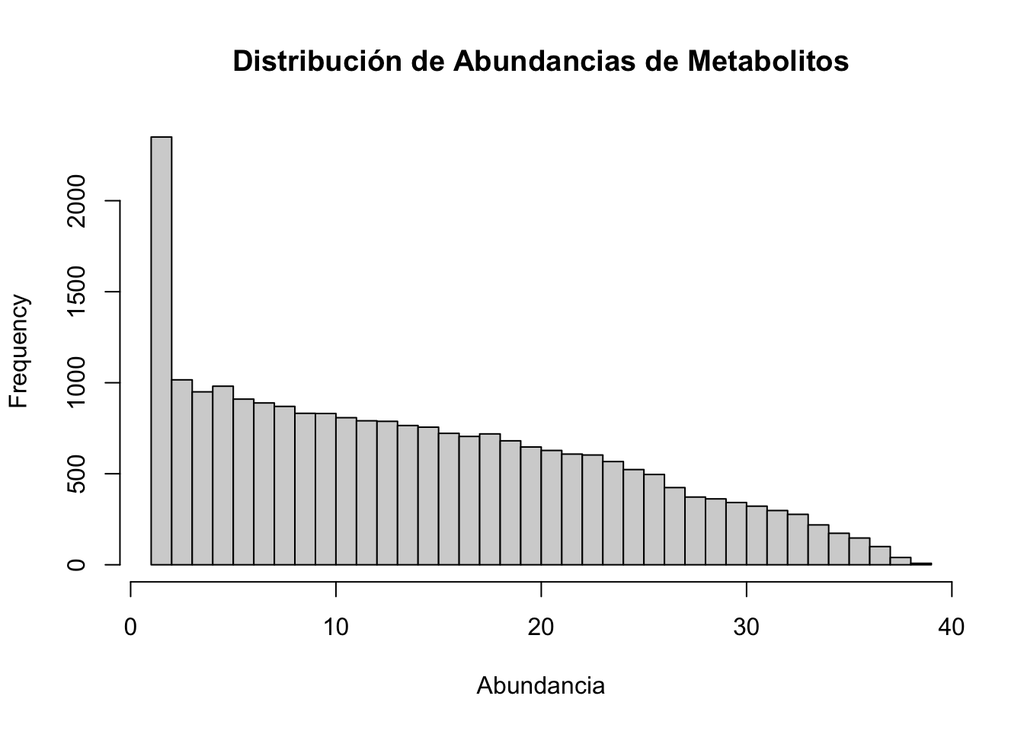

```r
# Graficar el histograma de abundancia de metabolitos
hist(
  as.vector(metabolites_data),
  main = "Distribución de Abundancias de Metabolitos",
  xlab = "Abundancia",
  breaks = 30
)
```

Conforme el gráfico avanza hacia la derecha, la frecuencia disminuye indicando que los metabolismos con abundancias mas altas son menos comunes por lo que sugiere que en concentraciones mas altas podrian representar compuestos abundantes en el organismo.

Ademas, que la distribución se encuentre de esta manera puede ser común dentro de datos biológicos al existir una gran diversidad en la expresión o por el contrario que necesite de una transformación de datos para un mejor análisis estadístico.

### 4.2.2 Boxplot de metabolitos por muestra

El siguiente análisis, es el de un diagrama de cajas para visualizar la distribución de metabolitos en cada muestra.

Como se vio en el histograma, la mayoría de los metabolitos tienen concentraciones pequeñas, sin embargo existen outliners lo que indica la presencia de algunos metabolitos con abundancia significativamente mayor que las demás muestras.

Para fines prácticos del análisis, se realizaron dos exploraciones por boxplot, la primera en donde solo se consideran todos los elementos de nuestro dataset. En donde se observa como es la distribución general de los metabolitos, sin embargo, para fines de análisis es mejor analizar en pequeños grupos para evaluar de mejor manera los cambios dentro de los boxplots.

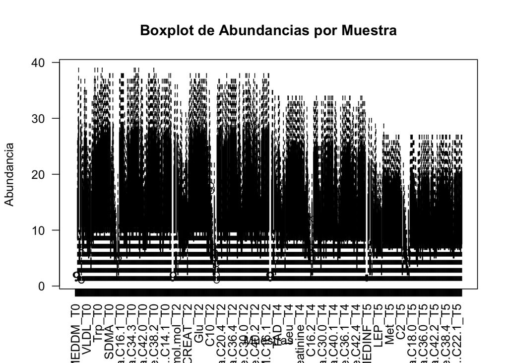

```r
boxplot(
  metabolites_data,
  main = "Boxplot de Abundancias por Muestra",
  xlab = "Muestras",
  ylab = "Abundancia",
  las = 2
)
```

Como se observa en el segundo boxplot, al seccionar los primeros 50 elementos, se pueden apreciar de mejor manera los datos, en donde se observan algunos outliners los cuales pueden ser de interés par algún analisis adicional.

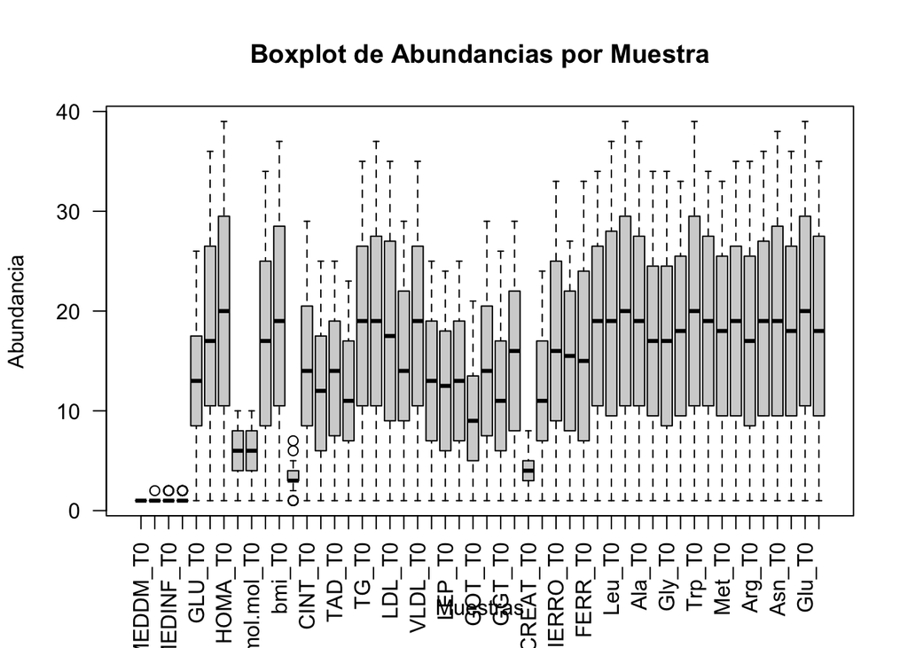

```r
# Boxplot de las abundancias de los primeros 50 metabolitos por muestra

boxplot(
  metabolites_data[, 1:50],
  main = "Boxplot de Abundancias por Muestra",
  xlab = "Muestras",
  ylab = "Abundancia",
  las = 2
)
```

#### 4.2.3 Cluster

El tercer analisis representa un clustering jerarquico de las muestras basado en la abundancia de los metabolitos. Este cuantifica la similitud o diferencia de la abundancia entre las muestras, el clusterin minimiza la varianza dentro de cada grupo de muestras lo cual brinda una estructura jerarquica qen donde la cohesion de los grupos es mayor y por ultimo un dendograma el cual es una representación visual donde las ramas representan los niveles de agrupamiento.

El tener el dendograma final, nos permite identificar dentro de los grupos observados indicativos de similitudes biologicas o experimentales, mediante la identificacion de patrones y relaciones de acuerdo a la variabilidad y similitud entre muestras.

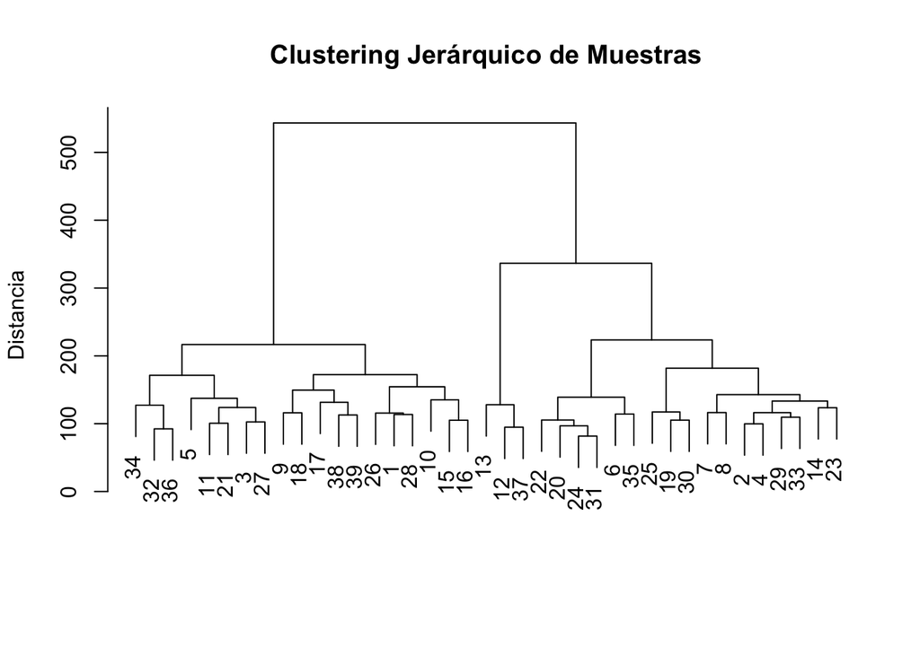

```r
# Asumiendo que tus datos están en un data frame o matriz llamado metabolite_clean
# y que las muestras están en las filas y los metabolitos en las columnas.

# 1. Calcular la matriz de distancias
dist_matrix <- dist(metabolite_clean, method = "euclidean")

# 2. Realizar el clustering jerárquico
hc <- hclust(dist_matrix, method = "ward.D2")

# 3. Graficar el dendrograma
plot(hc, main = "Clustering Jerárquico de Muestras", xlab = "", sub = "", ylab = "Distancia")
```

#### 4.2.4 Matriz de correlación

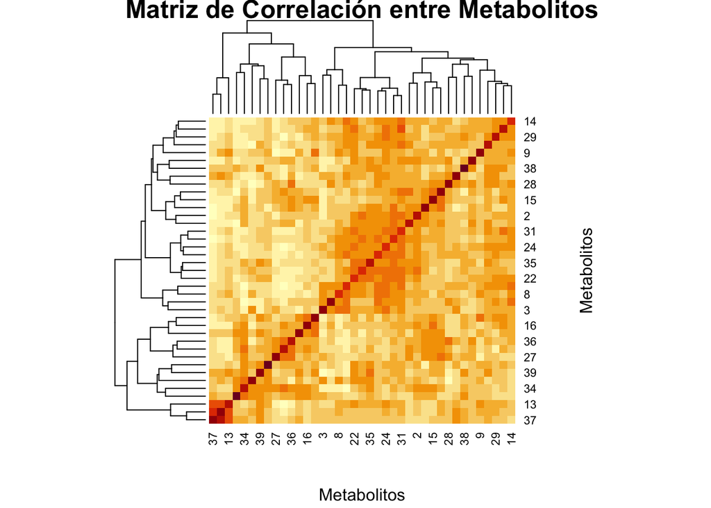

```r
cor_matrix <- cor(t(metabolites_data), use = "complete.obs")
heatmap(
  cor_matrix,
  main = "Matriz de Correlación entre Metabolitos",
  xlab = "Metabolitos",
  ylab = "Metabolitos"
)
```

#### 4.2.5 PCA

```r
library("viridis")
```

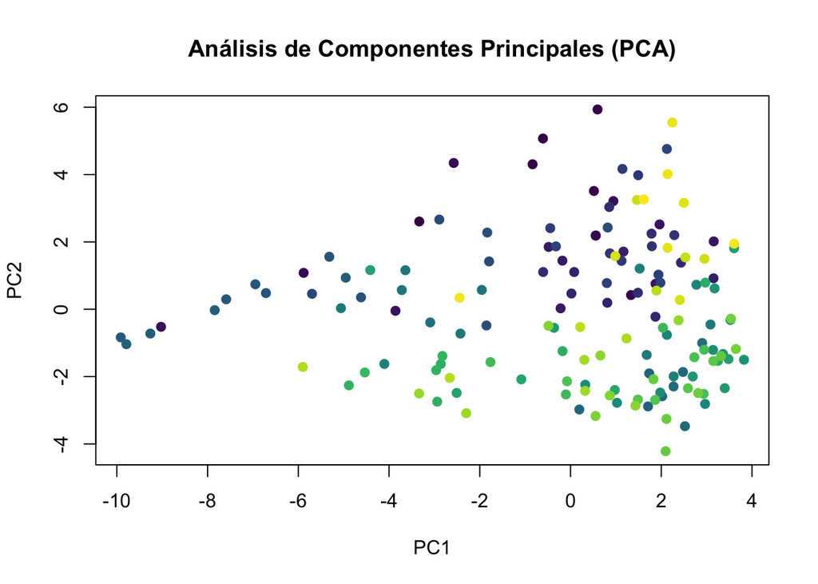

```r
# Realizar PCA
pca <- prcomp(t(metabolite_clean), scale. = TRUE)

# Graficar los primeros dos componentes con colores por grupo

colors <- viridis::viridis(n = nrow(pca$x))

plot(pca$x[, 1], pca$x[, 2],
     col = colors,
     pch = 19, # Cambia el estilo del punto si lo deseas
     xlab = "PC1", ylab = "PC2",
     main = "Análisis de Componentes Principales (PCA)")
```

#### 4.2.6 Analisis de coeficientes

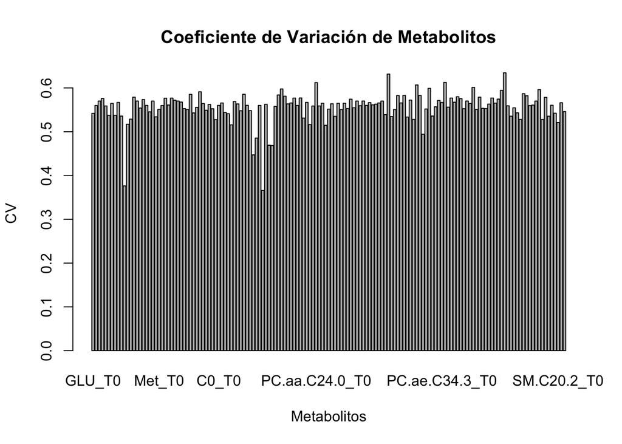

```r
## Analisis de coeficiente

cv <- apply(metabolite_clean, 2, function(x) sd(x, na.rm = TRUE) / mean(x, na.rm = TRUE))
barplot(cv, main = "Coeficiente de Variación de Metabolitos", ylab = "CV", xlab = "Metabolitos")
```

### 5.2 Limitaciones

La integración de diferentes enfoques estadísticos y visuales en el análisis de datos complejos, como los de metabolómica, ofrece perspectivas prometedoras para avanzar en la comprensión de los sistemas metabólicos. Se recomienda realizar estudios de seguimiento que incluyan mayor validación y refinamiento en la metodología para robustecer los resultados y profundizar en las posibles implicaciones biológicas de los patrones identificados.